# EAS 635.001 Homework 4

Author

Xiuyu Cao

Published

November 20, 2024

**In Homework 4, you will gain familiarity with (1) correspondence analysis and (2) regression. You will also practice performing and interpreting a PCA and cluster analysis**

**There are 3 questions total. Please be sure to submit your R code as well as the output in one of the following formats for full credit: .pdf, .html, .doc, .docx**

**The data set we will use for this homework is from the paper [Global effects of soil and climate on leaf photosynthetic traits and rates](https://onlinelibrary.wiley.com/doi/full/10.1111/geb.12296), you can access the open source metadata [here](https://datadryad.org/stash/dataset/doi:10.5061/dryad.j42m7). The research conducts multiple experiments to investigate the effects of soil and climate on leaf photosynthetic traits and rates at each site, which cause different resolutions between the vegetation traits and soil properties. To unify the resolution, the vegetation traits of each site were averaged. The data set after the averaging process is provided in the `soilveg_cleaned.csv` file.**

### 0.1 Load Packages

```r
library(tidyverse)
library(dendextend)
library(FactoMineR)
```

## 1 QUESTION 1

**For Q1, load in and use the data from the `soilveg_cleaned.csv` file.**

```r
soilveg <- read.csv("../data/hw04/soilveg_cleaned.csv")
```

### 1.1 PART A

**Run a correspondence analysis on the variable “GF” and “ELEV_Cate” of the data set and produce a plot of the outcome. Be sure to convert the original values of these two variables to a contingency table first**

```r
library(ca)
c_table <- table(soilveg$GF, soilveg$ELEV_Cate)  # get the contingency table for GF and ELEV_Cate
res.ca <- ca(c_table)
summary(res.ca)
```

```
Principal inertias (eigenvalues):

 dim    value      %   cum%   scree plot
 1      0.101804  76.3  76.3  *******************
 2      0.019059  14.3  90.6  ****
 3      0.010379   7.8  98.4  **
 4      0.002177   1.6 100.0
        -------- -----
 Total: 0.133420 100.0


Rows:
    name   mass  qlt  inr    k=1 cor ctr    k=2 cor ctr
1 |    F |   25  374   29 | -182 215   8 | -157 159  32 |
2 |    G |   44  918  297 | -904 916 356 |   47   3   5 |
3 |    H |  133  932  297 | -495 825 321 | -178 107 222 |
4 |    S |  251  966  105 |  -66  78  11 |  222 888 651 |
5 |    T |  537  994  244 |  239 945 302 |  -55  49  84 |
6 |    V |   10   83   29 | -149  56   2 | -102  26   5 |

Columns:
    name   mass  qlt  inr    k=1 cor ctr    k=2 cor ctr
1 | High |   59  594   65 |  207 291  25 | -211 303 138 |
2 |  Low |  153  265   56 | -101 209  15 |  -52  55  21 |
3 | Medm |   69  975  175 |  340 341  78 |  464 634 778 |
4 | VryH |  340  984  416 | -400 981 535 |   23   3  10 |
5 | VryL |  379  946  288 |  305 919 347 |  -51  26  52 |
```

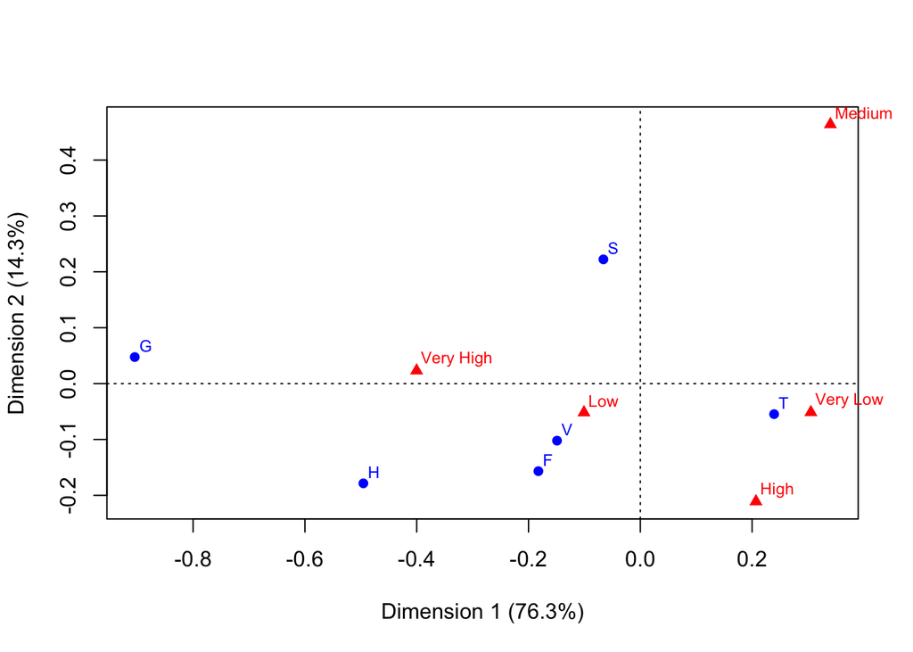

```r
plot(res.ca)
```

### 1.2 PART B

**Answer the following general questions:**

**1) In correspondence analysis, how “mass” is calculated? [useful reading link](https://vgonzenbach.github.io/multivariate-cookbook/correspondence-analysis.html#masses-and-weights)**

**2) In correspondence analysis, how “inertia” is calculated? (Bonus question)**

ANSWER: Chi-squared statistic of the table normalized by the total sum of the table.

**3) When would you want to use a correspondence analysis? Specifically, what type of data would be appropriate and how would these data be represented in the cells of your dataframe/spreadsheet?**

ANSWER: When analyzing relationships between categorical variables. Contingency table with counts of the number of times each combination of categories occurs is appropriate for correspondence analysis. each row and column is a different category of the variables, and cell values are the frequencies of each combination of categories occurs.

### 1.3 PART C

**Refer to the results of your correspondence analysis (performed in Q1 Part A) to answer the following questions:**

**1) What is the name of the column variable with the largest mass? Report the mass as well.**

ANSWER: `VryL` with a mass of 379.

**2) Based on visual inspection of the plot you produced in Part A, which row and column variables appear to be the most strongly correlated?**

ANSWER: `Low` and `V`; `Very Low` and `T`.

### 1.4 PART D

**1) Perform a chi-squared test on the contingency table you created in the last part using the `chi.sq()` function or “by hand”.**

```r
chisq.res <- chisq.test(c_table)
chisq.res
```

```
    Pearson's Chi-squared test

data:  c_table
X-squared = 27.084, df = 20, p-value = 0.1329
```

**2) How many degrees of freedom are there (using this specific dataset)? How did you calculate it (without using any R code)?**

ANSWER: 20. $df=(n_{row}-1)\times(n_{col}-1)$

**3) What is the null hypothesis of this test and what is the alternative hypothesis? Based on your results, do you reject or fail to reject the null hypothesis?**

ANSWER: The null hypothesis is that the two variables are independent. The alternative hypothesis is that the two variables are dependent. We fail to reject the null hypothesis for a P value of 0.13 > 0.05.

**4) Print the Pearson residuals (show code), report the largest and smallest values, and discuss the relevance of these values in the context of your data (i.e., what do the residual values you report tell you about your data).**

```r
chisq.res$residuals
```

```
           High         Low      Medium   Very High    Very Low
  F -0.54366028  0.27059974 -0.58722022  0.23050071  0.07511746
  G -0.72939681 -0.31934746 -0.78783860  2.25318145 -1.30641586
  H  0.31973732  0.92430271 -1.36457648  1.59194568 -1.63782073
  S -0.58444479  0.07590222  1.32383364  0.39990704 -0.76048614
  T  0.61324666 -0.40327783  0.17607625 -1.81527932  1.65710447
  V -0.34384095 -0.55264701 -0.37139068  0.38835222  0.27713265
```

```r
# largest residual
max(abs(chisq.res$residuals))
```

```
[1] 2.253181
```

```r
which(abs(chisq.res$residuals) == max(abs(chisq.res$residuals)), arr.ind = TRUE)
```

```
  row col
G   2   4
```

```r
# lowest residual
min(abs(chisq.res$residuals))
```

```
[1] 0.07511746
```

```r
which(abs(chisq.res$residuals) == min(abs(chisq.res$residuals)), arr.ind = TRUE)
```

```
  row col
F   1   5
```

LARGEST RESIDUAL: 2.253

LOWEST RESIDUAL: 0.075

RELEVANCE: The residuals are the differences between the observed and expected values. The largest residual indicates the largest difference between the observed and expected values, while the smallest residual indicates the smallest difference. The residuals can be used to identify the cells that contribute the most to the chi-squared statistic.

## 2 QUESTION 2

### 2.1 PART A

**Run a pairs plot on variables “Nmass”, “Amass”, “Aarea”, “RAD”, “PETf”, “SUNmean”, “pH”, “Pavail”, “PPTmean”, “SAND”, “TMPmean” of your data. Next, use `log()` to transform these variables and create a second pairs plot. Then answer the two questions below. To better demonstrate the traits of the pairs plot, we encourage you to use the `GGally` package, in particular the `ggpairs()` function for this question.**

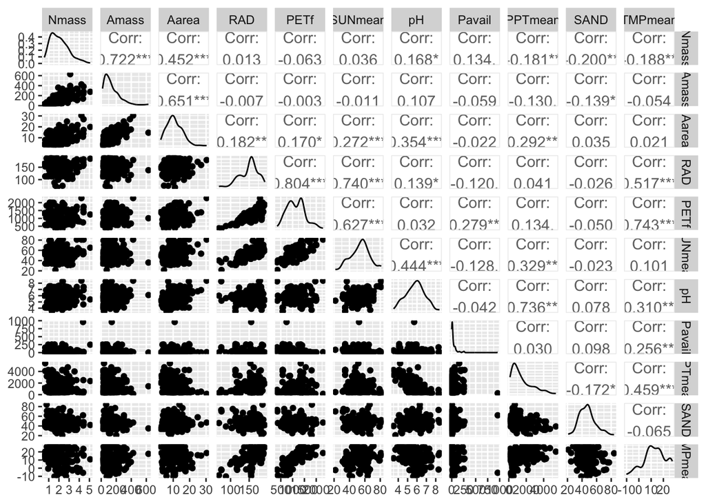

```r
# Your code for  pairs plot here
library(GGally)
soilveg4lm <- select(soilveg, Nmass, Amass, Aarea, RAD, PETf, SUNmean, pH, Pavail, PPTmean, SAND, TMPmean)
ggpairs(soilveg4lm)
```

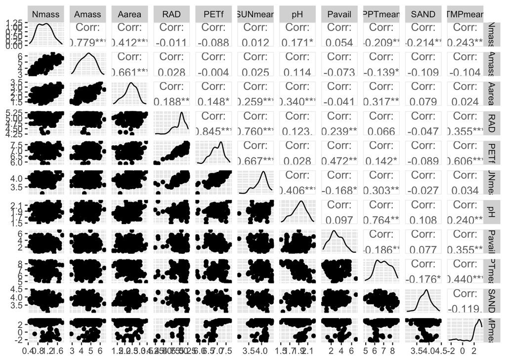

```r
# Your code for log-transformed pairs plot here
sym_log <- function(x) {
  sign(x) * log(1 + abs(x))
  }
soilveg4lm_log <- sym_log(soilveg4lm) %>%
  na.omit()
ggpairs(soilveg4lm_log)
```

**1) How do the plots (using the raw data vs. using the log-transformed data) differ?**

ANSWER: The log-transformed data shows a more linear relationship between the variables compared to the raw data. Large values are compressed and small values are expanded. While the effect is not so good when it comes to variables whose original range is narrow.

**2) Which data (raw or log-transformed) would you use for a linear regression? Why? (Hint: if you get stuck, try producing a boxplot of your data before and after log-transformation)**

ANSWER: I would use the log-transformed data because it better meets the assumptions of linear regression, such as linearity and homoscedasticity. And it’s good for originally skewed data.

### 2.2 PART B

**Start with a model only including the intercept term and perform a step-wise linear regression in forward direction using `Nmass` as your dependent variable and `RAD`, `PETf`, `SUNmean`, `pH`, `Pavail`, `PPTmean`, `SAND`, and `TMPmean` as your independent variables. Report the best fitting model and the corresponding** $R^2$ **and** $p$ **values. Additionally, plot the residuals for the best fitting model using a scatter plot (x = fitted values, y = residuals) and a QQ-plot.**

**To implement the step-wise linear regression, you can use the `stepAIC()` function from the `MASS` package.**

**Do this for the original variables listed above and their log-transformed counterparts.**

```r
library(MASS) # for stepAIC
# Step-wise linear regression for original data
lm.initial <- lm(Nmass ~ 1, data = soilveg)
lm.step <- stepAIC(lm.initial, direction='forward', scope=formula(Nmass ~ RAD + PETf + SUNmean + pH + Pavail + PPTmean + SAND + TMPmean))
```

```
Start:  AIC=-48.95
Nmass ~ 1

          Df Sum of Sq    RSS     AIC
+ SAND     1    6.3014 151.64 -55.219
+ TMPmean  1    5.5922 152.34 -54.272
+ PPTmean  1    5.1789 152.76 -53.722
+ pH       1    4.4708 153.47 -52.783
+ Pavail   1    2.8294 155.11 -50.624
<none>                 157.94 -48.954
+ PETf     1    0.6202 157.32 -47.753
+ SUNmean  1    0.2071 157.73 -47.220
+ RAD      1    0.0256 157.91 -46.987

Step:  AIC=-55.22
Nmass ~ SAND

          Df Sum of Sq    RSS     AIC
+ PPTmean  1    7.5466 144.09 -63.582
+ TMPmean  1    6.4160 145.22 -61.996
+ pH       1    5.3672 146.27 -60.535
+ Pavail   1    3.7508 147.88 -58.304
<none>                 151.64 -55.219
+ PETf     1    0.8341 150.80 -54.339
+ SUNmean  1    0.1577 151.48 -53.431
+ RAD      1    0.0090 151.63 -53.231

Step:  AIC=-63.58
Nmass ~ SAND + PPTmean

          Df Sum of Sq    RSS     AIC
+ Pavail   1    4.2801 139.81 -67.704
+ TMPmean  1    2.0749 142.01 -64.527
<none>                 144.09 -63.582
+ PETf     1    0.3225 143.77 -62.037
+ SUNmean  1    0.3194 143.77 -62.033
+ pH       1    0.1902 143.90 -61.851
+ RAD      1    0.0388 144.05 -61.637

Step:  AIC=-67.7
Nmass ~ SAND + PPTmean + Pavail

          Df Sum of Sq    RSS     AIC
<none>                 139.81 -67.704
+ TMPmean  1   0.71755 139.09 -66.748
+ pH       1   0.23208 139.58 -66.041
+ RAD      1   0.20020 139.61 -65.995
+ SUNmean  1   0.10543 139.70 -65.857
+ PETf     1   0.00042 139.81 -65.704
```

```r
summary(lm.step)
```

```
Call:
lm(formula = Nmass ~ SAND + PPTmean + Pavail, data = soilveg)

Residuals:
    Min      1Q  Median      3Q     Max
-1.6388 -0.6404 -0.1271  0.5087  2.7358

Coefficients:
              Estimate Std. Error t value Pr(>|t|)
(Intercept)  3.222e+00  2.929e-01  11.001  < 2e-16 ***
SAND        -2.112e-02  5.629e-03  -3.751 0.000231 ***
PPTmean     -1.804e-04  5.322e-05  -3.390 0.000842 ***
Pavail       1.745e-03  7.072e-04   2.468 0.014422 *
---
Signif. codes:  0 '***' 0.001 '**' 0.01 '*' 0.05 '.' 0.1 ' ' 1

Residual standard error: 0.8382 on 199 degrees of freedom
Multiple R-squared:  0.1148,    Adjusted R-squared:  0.1014
F-statistic: 8.601 on 3 and 199 DF,  p-value: 2.14e-05
```

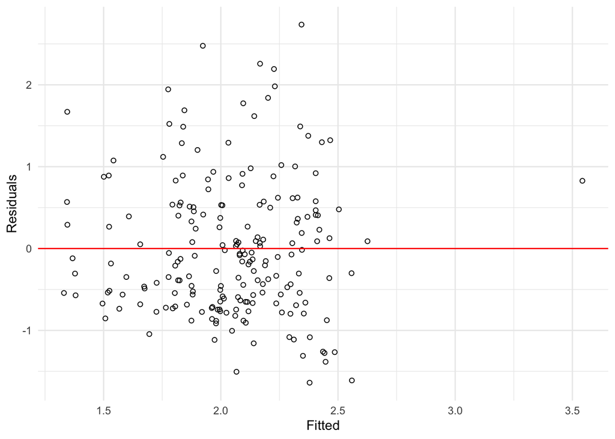

```r
#Plot the residuals for the best fitting model
ggplot() +
  geom_point(data = data.frame(fitted = fitted(lm.step), residuals = residuals(lm.step)),
             aes(x = fitted, y = residuals), shape=1) +
  geom_hline(yintercept = 0, color = "red") +  # Add horizontal line at 0
  xlab("Fitted") + ylab("Residuals") +
  theme_minimal()
```

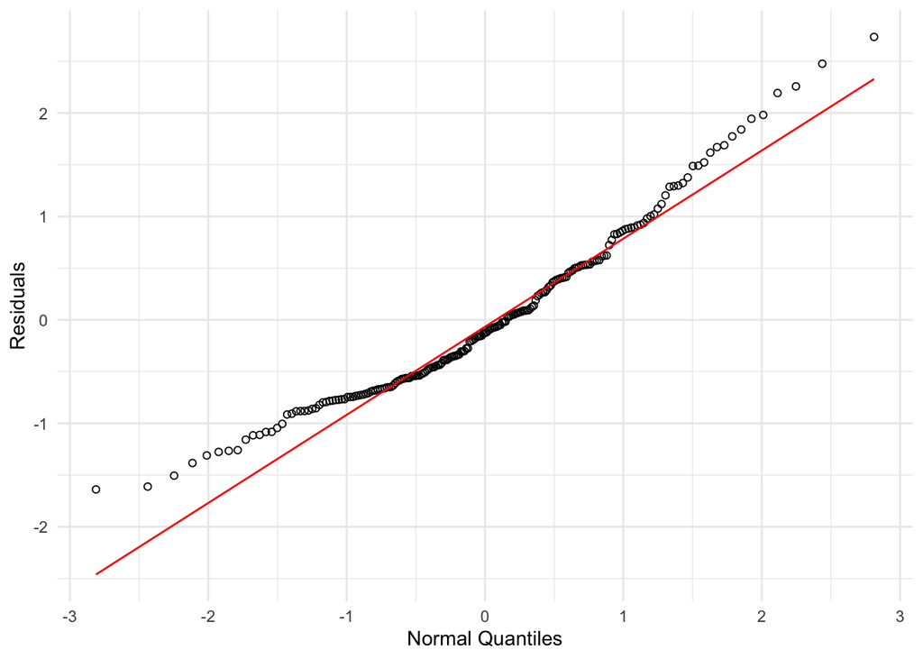

```r
#QQ-plot
ggplot() +
  geom_qq(data = data.frame(residuals = residuals(lm.step)), aes(sample = residuals), shape=1) +
  geom_qq_line(data = data.frame(residuals = residuals(lm.step)), aes(sample = residuals), color = "red") +
  theme_minimal() +
  xlab('Normal Quantiles') + ylab('Residuals')
```

```r
#Model,Residuals,QQ-plot for log-transformed data
soilveg.log <- soilveg %>%
  dplyr::select(Nmass, RAD, PETf, SUNmean, pH, Pavail, PPTmean, SAND, TMPmean) %>%
  na.omit() %>%
  sym_log()

# Step-wise linear regression
log_lm.initial <- lm(Nmass ~ 1, data = soilveg.log)
log_lm.step <- stepAIC(log_lm.initial, direction='forward', scope=formula(Nmass ~ RAD + PETf + SUNmean + pH + Pavail + PPTmean + SAND + TMPmean))
```

```
Start:  AIC=-514.09
Nmass ~ 1

          Df Sum of Sq    RSS     AIC
+ TMPmean  1   0.94381 15.029 -524.46
+ SAND     1   0.73442 15.238 -521.65
+ PPTmean  1   0.69884 15.274 -521.17
+ pH       1   0.46526 15.507 -518.09
<none>                 15.973 -514.09
+ PETf     1   0.12426 15.848 -513.68
+ Pavail   1   0.04573 15.927 -512.67
+ SUNmean  1   0.00213 15.971 -512.12
+ RAD      1   0.00207 15.971 -512.12

Step:  AIC=-524.46
Nmass ~ TMPmean

          Df Sum of Sq    RSS     AIC
+ SAND     1   0.96058 14.068 -535.86
+ pH       1   0.21428 14.815 -525.37
+ PPTmean  1   0.20675 14.822 -525.27
<none>                 15.029 -524.46
+ RAD      1   0.10276 14.926 -523.85
+ PETf     1   0.08826 14.941 -523.65
+ Pavail   1   0.01977 15.009 -522.72
+ SUNmean  1   0.00632 15.023 -522.54

Step:  AIC=-535.86
Nmass ~ TMPmean + SAND

          Df Sum of Sq    RSS     AIC
+ PPTmean  1   0.35502 13.713 -539.05
+ pH       1   0.29757 13.771 -538.20
<none>                 14.068 -535.86
+ RAD      1   0.09986 13.968 -535.31
+ PETf     1   0.07625 13.992 -534.97
+ Pavail   1   0.01082 14.057 -534.02
+ SUNmean  1   0.00324 14.065 -533.91

Step:  AIC=-539.05
Nmass ~ TMPmean + SAND + PPTmean

          Df Sum of Sq    RSS     AIC
<none>                 13.713 -539.05
+ RAD      1  0.063790 13.649 -538.00
+ PETf     1  0.029578 13.684 -537.49
+ SUNmean  1  0.028879 13.684 -537.48
+ pH       1  0.021495 13.692 -537.37
+ Pavail   1  0.014900 13.698 -537.27
```

```r
summary(log_lm.step)
```

```
Call:
lm(formula = Nmass ~ TMPmean + SAND + PPTmean, data = soilveg.log)

Residuals:
    Min      1Q  Median      3Q     Max
-0.5995 -0.1956 -0.0386  0.1792  0.7600

Coefficients:
            Estimate Std. Error t value Pr(>|t|)
(Intercept)  2.87844    0.39000   7.381 4.20e-12 ***
TMPmean     -0.04088    0.01487  -2.748  0.00654 **
SAND        -0.34125    0.08507  -4.011 8.54e-05 ***
PPTmean     -0.05780    0.02547  -2.270  0.02429 *
---
Signif. codes:  0 '***' 0.001 '**' 0.01 '*' 0.05 '.' 0.1 ' ' 1

Residual standard error: 0.2625 on 199 degrees of freedom
Multiple R-squared:  0.1415,    Adjusted R-squared:  0.1285
F-statistic: 10.93 on 3 and 199 DF,  p-value: 1.123e-06
```

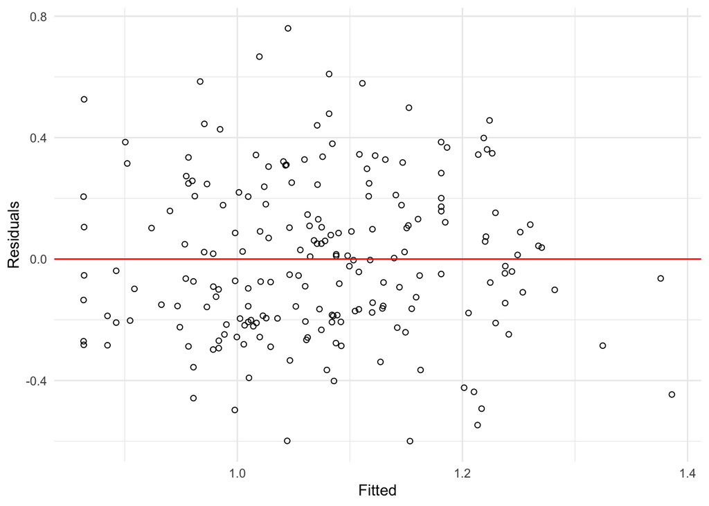

```r
# residual plot
ggplot() +
  geom_point(data = data.frame(fitted = fitted(log_lm.step), residuals = residuals(log_lm.step)),
             aes(x = fitted, y = residuals), shape=1) +
  geom_hline(yintercept = 0, color = "red") +  # Add horizontal line at 0
  xlab("Fitted") + ylab("Residuals") +
  theme_minimal()
```

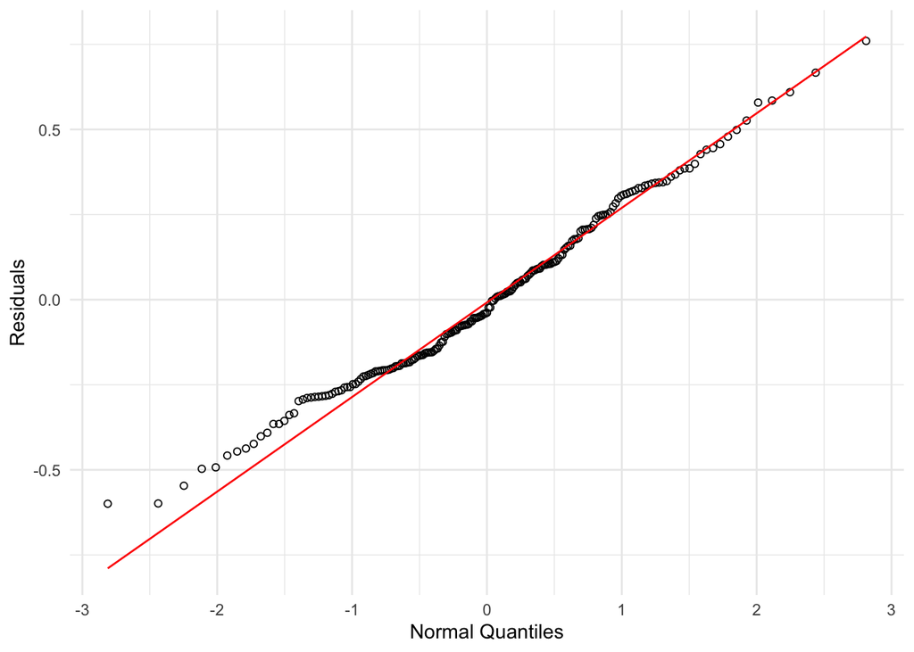

```r
# QQ-plot
ggplot() +
  geom_qq(data = data.frame(residuals = residuals(log_lm.step)), aes(sample = residuals), shape=1) +
  geom_qq_line(data = data.frame(residuals = residuals(log_lm.step)), aes(sample = residuals), color = "red") +
  theme_minimal() +
  xlab('Normal Quantiles') + ylab('Residuals')
```

BEST FITTING MODEL FOR ORIGINAL DATA IS: Nmass ~ SAND + PPTmean + Pavail

R2 FOR THIS MODEL: 0.10

P-VALUE FOR THIS MODEL: $2.14\times10^{-5}$

BEST FITTING MODEL FOR TRANSFORMED DATA IS: Nmass ~ TMPmean + SAND + PPTmean

R2 FOR THIS MODEL: 0.13

P-VALUE FOR THIS MODEL: $1.123\times10^{-6}$

### 2.3 PART C

**Based on your results from Part B, answer the following questions.**

**1) Does log-transforming your data matter (i.e., what was the impact of log-transforming your data and why)?**

ANSWER: The model formula is changed, and log-transforming the data also improved the model fit, as indicated by the higher $R^2$ value. Because the log-transformed data better met the assumptions of linear regression.

**2) Comment on the residual plots for each best-fitting model. What would you hope that these plots would look like (list 3 expectations total and provide at least one expectation for each type of plot)? Do your results meet your expectations?**

ANSWER: The residual plot should have a random pattern with no clear trend, scattering evenly around 0 along the fitted value. and the QQ-plot should have the residuals following a straight line. The residuals should be normally distributed. The log-transformed results meet my expectations. The result from the original data was not so good, as indicated in the QQ-plot, not so aligned with normal distribution.

**3) When would you want to log-transform a variable prior to analysis?**

ANSWER: When data is skewed, possibily causing non-normal distribution of the residuals.

**4) What do $R^2$ and $p$ values you obtained tell you about the model? Would you want to use these models to make predictions (remember to provide your reasoning)?**

ANSWER: $R^2$ tells me how much variability is explained by the model, and the $p$ value tells me whether the relationship between the predictors and the response variable is statistically significant.

**5) Other than transforming your data, name another modification of your dataset that you could/should make prior to running your regression? (You don’t need to really do that using R code)**

ANSWER: Clean the data, check for multicollinearity.

### 2.4 PART D

**Based on the best-fitting model for your raw data and the best-fitting model for your log-transformed data, plot the fitted vs. observed data. (Note: two plots should be produced, one using the raw data and the appropriate model and one using the log-transformed data and the appropriate model.) Include a 1-1 line on each plot and label your axes appropriately.**

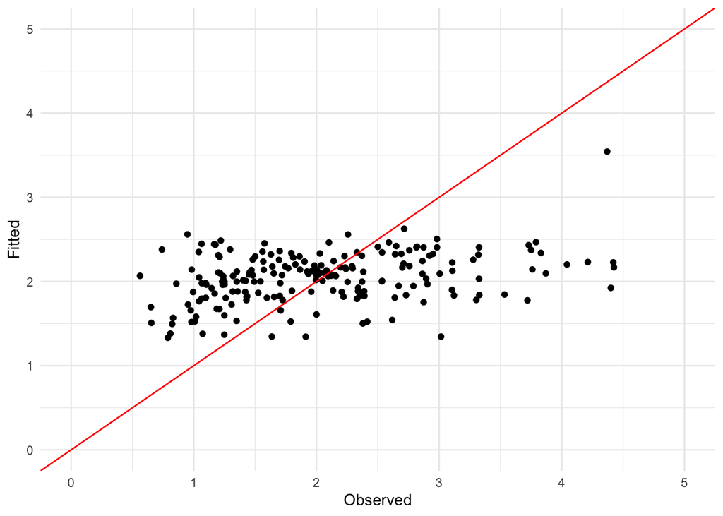

```r
#Plot for raw data
data2plot <- data.frame(fitted = fitted(lm.step), observed = soilveg$Nmass)

ggplot() +
  geom_point(data=data2plot, aes(x = observed, y = fitted)) +
  geom_abline(intercept = 0, slope = 1, color = "red") +  # Add 1-1 line
  xlab("Observed") + ylab("Fitted") +
  theme_minimal() +
  xlim(0, 5) + ylim(0, 5)
```

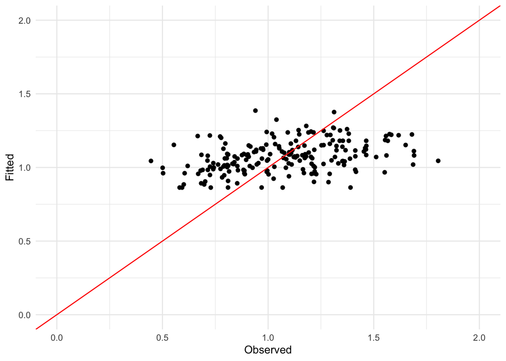

```r
#Plot for log-transformed data
data2plot <- data.frame(fitted = fitted(log_lm.step), observed = soilveg.log$Nmass)

ggplot() +
  geom_point(data=data2plot, aes(x = observed, y = fitted)) +
  geom_abline(intercept = 0, slope = 1, color = "red") +  # Add 1-1 line
  xlab("Observed") + ylab("Fitted") +
  theme_minimal() +
  xlim(0, 2) + ylim(0, 2)
```

### 2.5 PART E

**Run a multivariate regression on the log-transformed data from Question 2. The dependent variables you should include are: `Nmass`, and `Amass`; the independent variables you should include are `pH` and `PETf`. Report the coefficients.**

```r
soilveg.multiv <- soilveg %>%
  dplyr::select(Nmass, Amass, pH, PETf) %>%
  na.omit() %>%
  sym_log()

lm.multiv <- lm(cbind(Nmass, Amass) ~ pH + PETf, data = soilveg.multiv)
summary(lm.multiv)
```

```
Response Nmass :

Call:
lm(formula = Nmass ~ pH + PETf, data = soilveg.multiv)

Residuals:
     Min       1Q   Median       3Q      Max
-0.62396 -0.22111 -0.00952  0.20296  0.75984

Coefficients:
            Estimate Std. Error t value Pr(>|t|)
(Intercept)  0.97760    0.45573   2.145   0.0331 *
pH           0.32380    0.12967   2.497   0.0133 *
PETf        -0.07483    0.05580  -1.341   0.1814
---
Signif. codes:  0 '***' 0.001 '**' 0.01 '*' 0.05 '.' 0.1 ' ' 1

Residual standard error: 0.2772 on 200 degrees of freedom
Multiple R-squared:  0.03778,   Adjusted R-squared:  0.02816
F-statistic: 3.926 on 2 and 200 DF,  p-value: 0.02125


Response Amass :

Call:
lm(formula = Amass ~ pH + PETf, data = soilveg.multiv)

Residuals:
     Min       1Q   Median       3Q      Max
-1.74750 -0.57411  0.04652  0.58550  1.77889

Coefficients:
            Estimate Std. Error t value Pr(>|t|)
(Intercept)  3.70239    1.17790   3.143  0.00193 **
pH           0.54276    0.33514   1.620  0.10691
PETf        -0.01435    0.14422  -0.100  0.92083
---
Signif. codes:  0 '***' 0.001 '**' 0.01 '*' 0.05 '.' 0.1 ' ' 1

Residual standard error: 0.7165 on 200 degrees of freedom
Multiple R-squared:  0.01296,   Adjusted R-squared:  0.003088
F-statistic: 1.313 on 2 and 200 DF,  p-value: 0.2714
```

```r
# Report the coefficients
coefficients(lm.multiv)
```

```
                  Nmass       Amass
(Intercept)  0.97759526  3.70238871
pH           0.32379693  0.54275907
PETf        -0.07483091 -0.01435259
```

### 2.6 PART F

**Answer the following questions:**

**1) When might it be better to use multivariate regression instead of modelling multiple dependent variables separately?**

ANSWER: When the dependent variables are correlated, and the independent variables are the same for all dependent variables.

**2) When would you want to use a GLM instead of a typical multiple/multivariate regression?**

ANSWER: When the dependent variable is not normally distributed, or when the relationship between the dependent and independent variables is not linear.

**3) When is it appropriate to use logistic regression?**

ANSWER: When the dependent variable is binary.

## 3 QUESTION 3

### 3.1 PART A

**Perform a PCA on the raw data(soilveg_cleaned.csv). Only use the climate variables (columns 23-40) in your PCA. Summary your PCA result, based on the result, report the number of components you would recommend proceeding with in an analysis as well as the total variance explained by these components. And produce a biplot.**

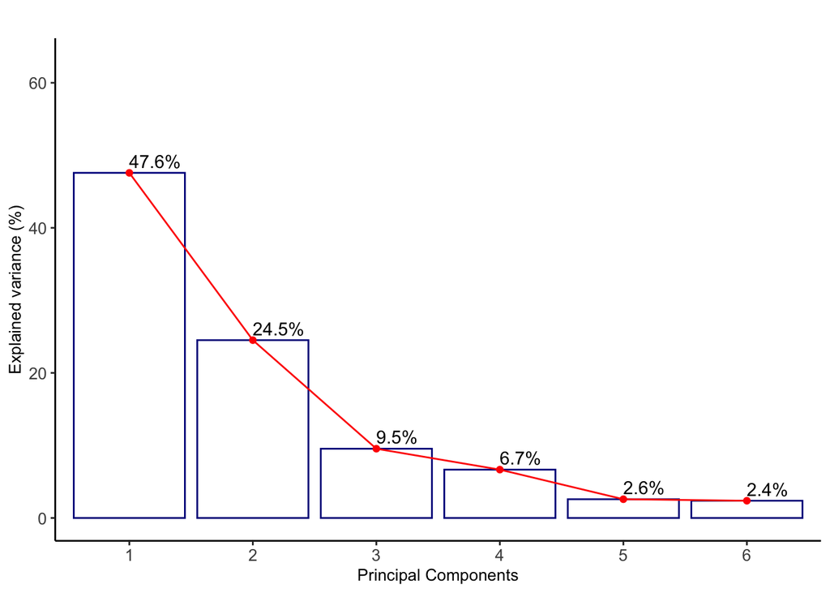

```r
library(factoextra)
# Your PCA code here
soilveg <- read.csv("../data/hw04/soilveg_cleaned.csv")
soilveg_climate <- soilveg[, 23:40]

pca.res <- PCA(soilveg_climate, graph=F)


ind <- get_pca_ind(pca.res)  # get result
result <- soilveg_climate
# combine the results with the original data
result$PC1 <- ind$coord[,1]
result$PC2 <- ind$coord[,2]
result$PC3 <- ind$coord[,3]

## Scree plot
fviz_eig(pca.res, addlabels=T,
                    barfill="white", barcolor ="darkblue",
                    ncp = 6, labelsize = 2,
                    linecolor ="red") +
  ylim(0, 63) +
  theme_classic() +
  labs(title = "", x = "Principal Components", y = "Explained variance (%)") +
  theme(axis.title = element_text(size = 10),
        axis.text = element_text(size = 10))
```

ANSWER: I will use 3 PCs which explained 81.6% of the variance.

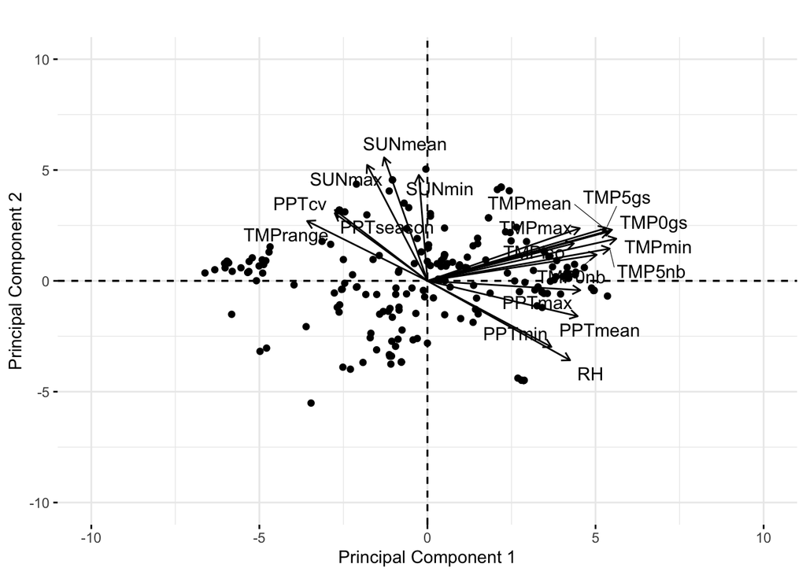

```r
# Your code for biplot here
fviz_pca_biplot(pca.res, label='var', repel=T,  # set loading label paras
                col.var='black') +  # color of the loading arrows
  labs(title = "", x = "Principal Component 1", y = "Principal Component 2") +
  xlim(-10, 10) + ylim(-10, 10)
```

### 3.2 PART B

**Perform a backward step-wise linear regression for each of the following dependent variables: `Nmass`, `Amass`, and `SLA`. Include your PCA scores (from Question 3 Part A) as independent variables in your regression (just include the scores for the first 3 components.**

```r
# Your code for backward step-wise linear regression here
dependent <- dplyr::select(soilveg, Nmass, Amass, SLA)
independent <- dplyr::select(result, PC1, PC2, PC3)
soilveg4lm <- cbind(dependent, independent)

# backward step-wise linear regression
initial_lm.Nmass <- lm(Nmass ~ PC1 + PC2 + PC3, data = soilveg4lm)
step_lm.Nmass <- stepAIC(initial_lm.Nmass, direction='backward')
```

```
Start:  AIC=-53.31
Nmass ~ PC1 + PC2 + PC3

       Df Sum of Sq    RSS     AIC
- PC2   1    0.0174 150.10 -55.287
- PC3   1    0.4358 150.52 -54.722
<none>              150.08 -53.311
- PC1   1    7.4024 157.49 -45.537

Step:  AIC=-55.29
Nmass ~ PC1 + PC3

       Df Sum of Sq    RSS     AIC
- PC3   1    0.4358 150.53 -56.699
<none>              150.10 -55.287
- PC1   1    7.4024 157.50 -47.515

Step:  AIC=-56.7
Nmass ~ PC1

       Df Sum of Sq    RSS     AIC
<none>              150.53 -56.699
- PC1   1    7.4024 157.94 -48.954
```

```r
summary(step_lm.Nmass)
```

```
Call:
lm(formula = Nmass ~ PC1, data = soilveg4lm)

Residuals:
    Min      1Q  Median      3Q     Max
-1.4553 -0.6548 -0.1573  0.4854  3.1915

Coefficients:
            Estimate Std. Error t value Pr(>|t|)
(Intercept)  2.04375    0.06074  33.648  < 2e-16 ***
PC1         -0.06525    0.02075  -3.144  0.00192 **
---
Signif. codes:  0 '***' 0.001 '**' 0.01 '*' 0.05 '.' 0.1 ' ' 1

Residual standard error: 0.8654 on 201 degrees of freedom
Multiple R-squared:  0.04687,   Adjusted R-squared:  0.04213
F-statistic: 9.884 on 1 and 201 DF,  p-value: 0.00192
```

```r
initial_lm.Amass <- lm(Amass ~ PC1 + PC2 + PC3, data = soilveg4lm)
step_lm.Amass <- stepAIC(initial_lm.Amass, direction='backward')
```

```
Start:  AIC=1848.68
Amass ~ PC1 + PC2 + PC3

       Df Sum of Sq     RSS    AIC
- PC3   1     279.5 1759907 1846.7
- PC2   1     355.6 1759983 1846.7
<none>              1759627 1848.7
- PC1   1   19631.1 1779258 1848.9

Step:  AIC=1846.72
Amass ~ PC1 + PC2

       Df Sum of Sq     RSS    AIC
- PC2   1     355.6 1760262 1844.8
<none>              1759907 1846.7
- PC1   1   19631.1 1779538 1847.0

Step:  AIC=1844.76
Amass ~ PC1

       Df Sum of Sq     RSS    AIC
<none>              1760262 1844.8
- PC1   1     19631 1779893 1845.0
```

```r
summary(step_lm.Amass)
```

```
Call:
lm(formula = Amass ~ PC1, data = soilveg4lm)

Residuals:
    Min      1Q  Median      3Q     Max
-125.64  -69.83  -23.89   47.62  503.42

Coefficients:
            Estimate Std. Error t value Pr(>|t|)
(Intercept)  130.722      6.568  19.902   <2e-16 ***
PC1           -3.360      2.244  -1.497    0.136
---
Signif. codes:  0 '***' 0.001 '**' 0.01 '*' 0.05 '.' 0.1 ' ' 1

Residual standard error: 93.58 on 201 degrees of freedom
Multiple R-squared:  0.01103,   Adjusted R-squared:  0.006109
F-statistic: 2.242 on 1 and 201 DF,  p-value: 0.1359
```

```r
initial_lm.SLA <- lm(SLA ~ PC1 + PC2 + PC3, data = soilveg4lm)
step_lm.SLA <- stepAIC(initial_lm.SLA, direction='backward')
```

```
Start:  AIC=1715.79
SLA ~ PC1 + PC2 + PC3

       Df Sum of Sq    RSS    AIC
- PC1   1      1678 916005 1714.2
- PC3   1      3197 917525 1714.5
<none>              914327 1715.8
- PC2   1     50077 964404 1724.6

Step:  AIC=1714.16
SLA ~ PC2 + PC3

       Df Sum of Sq    RSS    AIC
- PC3   1      3197 919202 1712.9
<none>              916005 1714.2
- PC2   1     50077 966082 1723.0

Step:  AIC=1712.87
SLA ~ PC2

       Df Sum of Sq    RSS    AIC
<none>              919202 1712.9
- PC2   1     50077 969279 1721.6
```

```r
summary(step_lm.SLA)
```

```
Call:
lm(formula = SLA ~ PC2, data = soilveg4lm)

Residuals:
    Min      1Q  Median      3Q     Max
-110.75  -49.82  -13.88   35.49  290.87

Coefficients:
            Estimate Std. Error t value Pr(>|t|)
(Intercept)  121.553      4.746  25.610  < 2e-16 ***
PC2           -7.477      2.259  -3.309  0.00111 **
---
Signif. codes:  0 '***' 0.001 '**' 0.01 '*' 0.05 '.' 0.1 ' ' 1

Residual standard error: 67.63 on 201 degrees of freedom
Multiple R-squared:  0.05166,   Adjusted R-squared:  0.04695
F-statistic: 10.95 on 1 and 201 DF,  p-value: 0.001109
```

### 3.3 PART C

**Based on your model results from Question 3 Part B, answer the question below:**

**Which aspect of the vegetation response (`Nmass`, `Amass`, `SLA`) is found to be impacted more by sun duration related variables rather than by other weather variables?**

ANSWER: According to the bi-plot, sun duration related variables are more correlated with PC2. Therefore, according to the linear model summaries, `SLA` is impacted more by sun duration related variables rather than by other weather variables.

### 3.4 PART D

**Filter your original data set for Continent = North America. Then perform a cluster analysis on your subsetted data (only use these variables: `Nmass`, `Aarea`, `RAD` ,`PETf`, `SUNmean`, `pH`, `Pavail`, `PPTmean`, `SAND`, `TMPmean`, and also scale them). Your distance calculations should use the “Euclidean” distance and use the “complete” method of clustering with `hclust()`. Produce a dendrogram to visualize your results.**

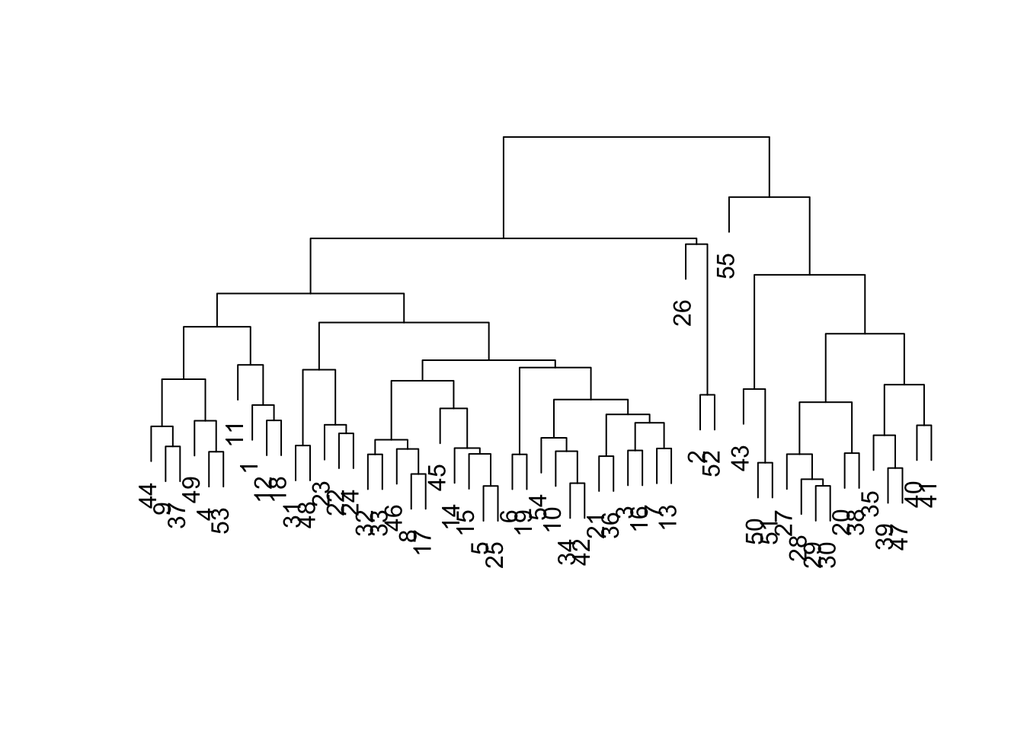

```r
#Your code for cluster analysis here
data4cluster <- soilveg %>%
  filter(Continent == "North America") %>%
  dplyr::select(Nmass, Aarea, RAD, PETf, SUNmean, pH, Pavail, PPTmean, SAND, TMPmean) %>%
  scale

distance <- dist(data4cluster, method='euclidean')

clust <- hclust(distance)
plot(clust, xlab='', sub='', ylab='', yaxt='n', main='')
```

### 3.5 (Bonus) PART E

**There are different packages for correspondence analysis in R. In Question 1 you may have already used the `ca` package, or the `FactorMineR` package to perform a correspondence analysis, but the results of these two packages are not always the SAME. In this part, you are asked to perform a correspondence analysis on the same variables “GF” and “ELEV_Cate” of the original data (soilveg_cleaned.csv) using the other package that you did not use in Question 1, list the summary of the correspondence analysis, and in particular, compare the results of `row$coord`(ca) and `row$coord`(FactorMineR),use any resource you can find to explain the differences of these two results——Why are they different in your opinion?**

```r
#Your code for Bonus part here
library(FactoMineR)

c_table <- table(soilveg$GF, soilveg$ELEV_Cate)
# use the FactoMineR package
res.ca.Facto <- FactoMineR::CA(c_table, graph = F)
summary(res.ca.Facto)
```

```
Call:
FactoMineR::CA(X = c_table, graph = F)

The chi square of independence between the two variables is equal to 27.08429 (p-value =  0.1329091 ).

Eigenvalues
                       Dim.1   Dim.2   Dim.3   Dim.4
Variance               0.102   0.019   0.010   0.002
% of var.             76.303  14.285   7.779   1.632
Cumulative % of var.  76.303  90.589  98.368 100.000

Rows
            Iner*1000    Dim.1    ctr   cos2    Dim.2    ctr   cos2    Dim.3
F         |     3.805 | -0.182  0.805  0.215 | -0.157  3.173  0.159 | -0.138
G         |    39.597 | -0.904 35.619  0.916 |  0.047  0.524  0.003 | -0.264
H         |    39.583 | -0.495 32.066  0.825 | -0.178 22.226  0.107 |  0.142
S         |    13.981 | -0.066  1.075  0.078 |  0.222 65.124  0.888 |  0.042
T         |    32.566 |  0.239 30.221  0.945 | -0.055  8.415  0.049 | -0.016
V         |     3.888 | -0.149  0.215  0.056 | -0.102  0.539  0.026 | -0.601
             ctr   cos2
F          4.492  0.123 |
G         29.801  0.078 |
H         25.953  0.068 |
S          4.244  0.032 |
T          1.276  0.004 |
V         34.234  0.914 |

Columns
            Iner*1000    Dim.1    ctr   cos2    Dim.2    ctr   cos2    Dim.3
High      |     8.698 |  0.207  2.485  0.291 | -0.211 13.812  0.303 |  0.199
Low       |     7.406 | -0.101  1.523  0.209 | -0.052  2.148  0.055 |  0.175
Medium    |    23.394 |  0.340  7.833  0.341 |  0.464 77.837  0.634 |  0.088
Very High |    55.518 | -0.400 53.472  0.981 |  0.023  0.956  0.003 | -0.049
Very Low  |    38.404 |  0.305 34.686  0.919 | -0.051  5.247  0.026 | -0.073
             ctr   cos2
High      22.453  0.268 |
Low       44.877  0.629 |
Medium     5.152  0.023 |
Very High  7.888  0.015 |
Very Low  19.629  0.053 |
```

```r
# use the ca package
res.ca.ca <- ca::ca(c_table)
summary(res.ca.ca)
```

```
Principal inertias (eigenvalues):

 dim    value      %   cum%   scree plot
 1      0.101804  76.3  76.3  *******************
 2      0.019059  14.3  90.6  ****
 3      0.010379   7.8  98.4  **
 4      0.002177   1.6 100.0
        -------- -----
 Total: 0.133420 100.0


Rows:
    name   mass  qlt  inr    k=1 cor ctr    k=2 cor ctr
1 |    F |   25  374   29 | -182 215   8 | -157 159  32 |
2 |    G |   44  918  297 | -904 916 356 |   47   3   5 |
3 |    H |  133  932  297 | -495 825 321 | -178 107 222 |
4 |    S |  251  966  105 |  -66  78  11 |  222 888 651 |
5 |    T |  537  994  244 |  239 945 302 |  -55  49  84 |
6 |    V |   10   83   29 | -149  56   2 | -102  26   5 |

Columns:
    name   mass  qlt  inr    k=1 cor ctr    k=2 cor ctr
1 | High |   59  594   65 |  207 291  25 | -211 303 138 |
2 |  Low |  153  265   56 | -101 209  15 |  -52  55  21 |
3 | Medm |   69  975  175 |  340 341  78 |  464 634 778 |
4 | VryH |  340  984  416 | -400 981 535 |   23   3  10 |
5 | VryL |  379  946  288 |  305 919 347 |  -51  26  52 |
```

```r
# compare the row coords
res.ca.Facto$row$coord
```

```
        Dim 1       Dim 2       Dim 3        Dim 4
F -0.18235945 -0.15668240 -0.13758357 -0.278827403
G -0.90437409  0.04747445 -0.26413400  0.056787500
H -0.49542094 -0.17846361  0.14231395  0.007899183
S -0.06599573  0.22227312  0.04187072 -0.011654004
T  0.23936976 -0.05465213 -0.01570332  0.010931893
V -0.14899641 -0.10209383 -0.60054910  0.036274678
```

```r
res.ca.ca$rowcoord
```

```
        Dim1       Dim2       Dim3       Dim4
F -0.5715387 -1.1349226 -1.3504640 -5.9753642
G -2.8344281  0.3438793 -2.5926312  1.2169751
H -1.5527148 -1.2926938  1.3968955  0.1692821
S -0.2068393  1.6100262  0.4109859 -0.2497492
T  0.7502165 -0.3958705 -0.1541373  0.2342741
V -0.4669745 -0.7395124 -5.8947441  0.7773784
```

They are different due to differences in their default scaling methods and normalization approaches.